# New York City’s bike share 2018

Lenka Rozborilova

18/01/2021

This report presents an insight into the New York City’s bike share system - one of the largest bike shares in the US. The following descriptive and explanatory analysis was carried out on an available data set containing observations of 10 bikes monitored during the year of 2018.

**Data**

| bike_id | start_time | stop_time | start_station | end_station | type | birth_year | gender | date | hour | day | weekday | month | year | duration | duration_hrs |
| --- | --- | --- | --- | --- | --- | --- | --- | --- | --- | --- | --- | --- | --- | --- | --- |
| 26301 | 2018-02-26 19:11:03 | 2018-02-26 19:15:40 | 3186 | 3203 | Subscriber | 1986 | Male | 2018-02-26 | 19 | Mon | weekday | Feb | 2018 | 277.098000049591s (~4.62 minutes) | 0.07697167 |
| 26301 | 2018-02-27 07:52:49 | 2018-02-27 07:58:13 | 3203 | 3202 | Subscriber | 1979 | Male | 2018-02-27 | 7 | Tue | weekday | Feb | 2018 | 323.924000024796s (~5.4 minutes) | 0.08997889 |
| 26301 | 2018-02-27 12:03:27 | 2018-02-27 12:04:54 | 3202 | 3638 | Subscriber | 1963 | Male | 2018-02-27 | 12 | Tue | weekday | Feb | 2018 | 86.5269999504089s (~1.44 minutes) | 0.02403528 |
| 26301 | 2018-02-27 13:53:51 | 2018-02-27 14:21:04 | 3638 | 3638 | Subscriber | 1984 | Male | 2018-02-27 | 13 | Tue | weekday | Feb | 2018 | 1632.94499993324s (~27.22 minutes) | 0.45359583 |
| 26301 | 2018-02-27 14:30:42 | 2018-02-27 14:33:11 | 3638 | 3187 | Subscriber | 1980 | Male | 2018-02-27 | 14 | Tue | weekday | Feb | 2018 | 148.53400015831s (~2.48 minutes) | 0.04125944 |
| 26301 | 2018-02-27 16:31:04 | 2018-02-27 16:33:27 | 3187 | 3638 | Subscriber | 1980 | Male | 2018-02-27 | 16 | Tue | weekday | Feb | 2018 | 143.954999923706s (~2.4 minutes) | 0.03998750 |

### Bike hire throughout the 2018

- how many times was EACH bike hired daily on average
- the bike hire frequency went up during the summer months, with August being the busiest month of the year
- the winter months were the most quiet ones

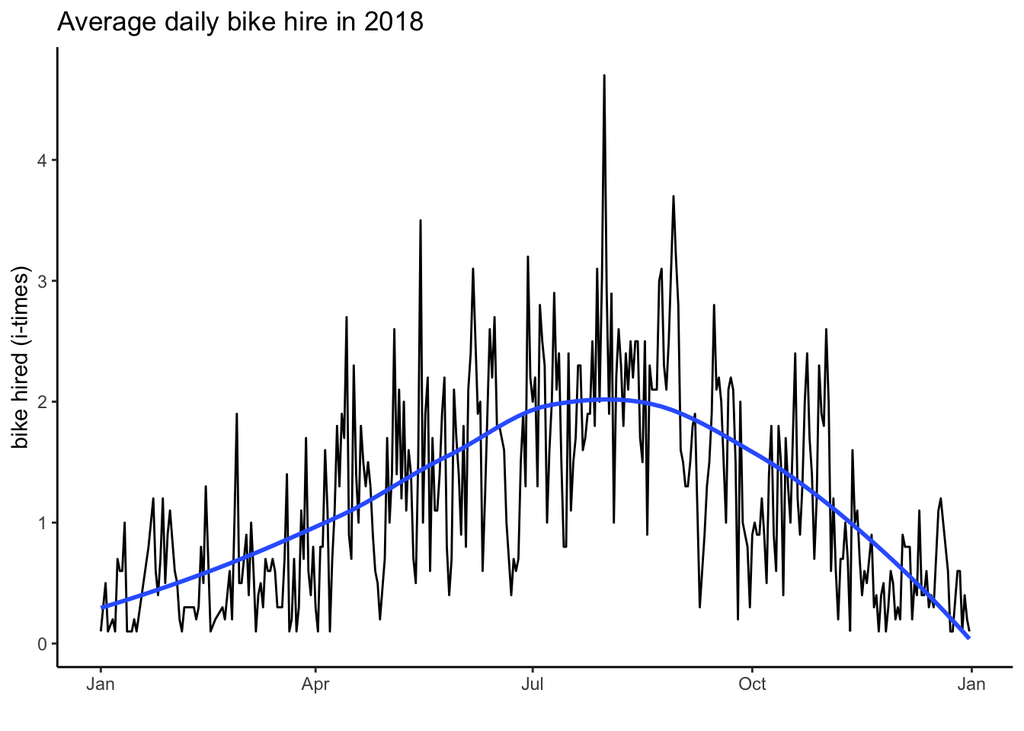

### Typical bike usage throughout a day

- split by the week days and the weekend days
- for the week days, the most popular bike hire times were 7-10AM and 5-8PM
- for the weekend days, the most popular hours are spread over the daylight hours, between 10AM-6PM

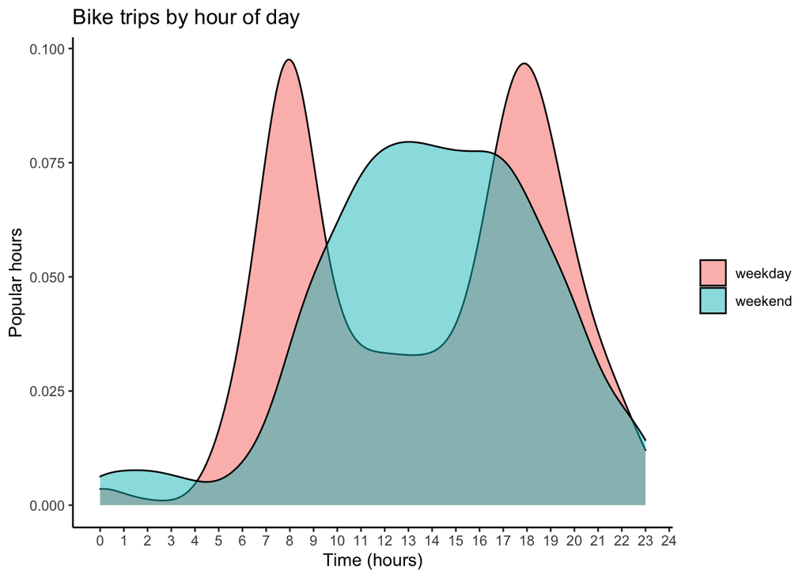

**Quiz - answer**

| weekday | year | avg_time |
| --- | --- | --- |
| weekday | 2018 | 851.126945206854s (~14.19 minutes) |
| weekend | 2018 | 887.205980766049s (~14.79 minutes) |

### Hours each bike was used during the year

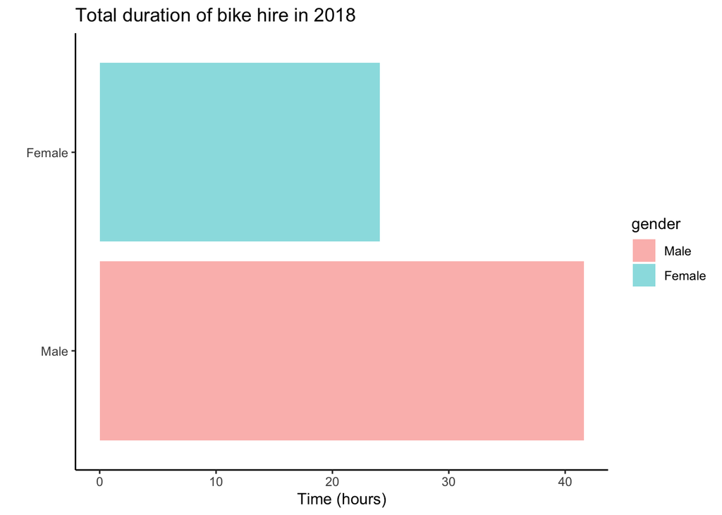

### Geographical spread of the start/end points of bike hires

[interactive chart not shown]

### Prediction

[figure not shown]